# Data viz

Réka Solymosi, Sam Langton & Emily Buehler

4 July 2019

A picture is worth a thousand words; when presenting and interpreting data this basic idea also applies. There has been, indeed, a growing shift in data analysis toward more visual approaches to both interpretation and dissemination of numerical analysis. Part of the new data revolution consists in the mixing of ideas from visualisation of statistical analysis and visual design. Data visualisation is one of the most interesting areas of development in the field.

Good graphics not only help researchers to make their data easier to understand by the general public. They are also a useful way for understanding the data ourselves. In many ways it is very often a more intuitive way to understand patterns in our data than trying to look at numerical results presented in a tabular form.

Recent research has revealed that papers which have good graphics are perceived as overall more clear and more interesting, and their authors perceived as smarter (see [this presentation](https://vimeo.com/181771433))

As with other aspects of R, there are a number of core functions that can be used to produce graphics. For example, we’ve already used `plot()`. However these offer limited possibilities for building graphs, and it is by exploring packages that are developed especially for graphing.

The package we will be using throughout this tutorial is `ggplot2`. The aim of ggplot is to implement the [grammar of graphics](http://www.springer.com/statistics/computational+statistics/book/978-0-387-24544-7). The `ggplot2` package has excellent online [documentation](http://ggplot2.org/).

If you don’t already have the package installed, you will need to do so using the `install.packages()` function. Remember that ggplot2 is part of the tidyverse, so if you already have the tidyverse package installed, you should be all set.

You will then need to load up the package

```r
library(ggplot2)
```

The grammar of graphics defines various components (layers) of the graphic. Some of the most important are:

- **The data**: For using `ggplot2` the data has to be stored as a data frame
- **The aesthetics**: They describe the visual characteristics that represent the data you are interested in (e.g., position, size, colour, shape, transparency).
- **The geoms**: They describe the objects that represent the data (e.g., points, lines, polygons, etc.).
- **Facets**: They describe how data is split into subsets and displayed as multiple small graphs.
- **Stats**: They describe statistical transformations that typically summarise data.

# Anatomy of a plot

Essentially the philosophy behind the grammer of graphics is that all data visualisations are made up of layers. ggplot2 is based on the grammar of graphics: every graph can be built using the same few components. You will notice as we go along that each line of code used to build a visualisation with ggplot2 refers to one of these layers (e.g. data, aesthetics).

Take this example (all taken from *Wickham, H. (2010). A layered grammar of graphics. Journal of Computational and Graphical Statistics, 19(1), 3-28.*)

You have a table such as:

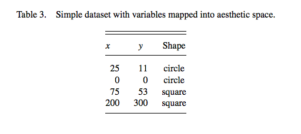

You then want to plot this. To do so, you want to create a plot that combines the following layers:

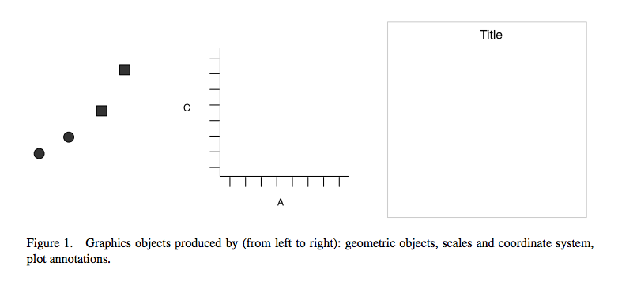

This will result in a final plot:

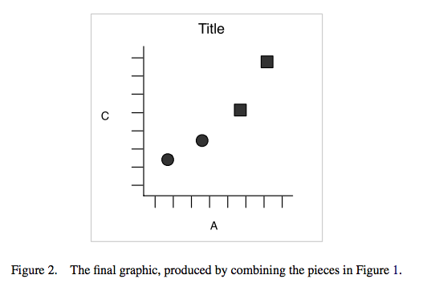

The three key layers for visualising data according to the grammar of graphics can be summarised like [this](https://www.science-craft.com/2014/07/08/introducing-the-grammar-of-graphics-plotting-concept/) (below). There are more than three layers in total, but these three are fundamental to creating any basic data visualisation:

[figure not shown]

Let’s have a look at this with some data. We have gone through the exercise of tidying the football banning order offences yesterday, so let’s use this data now, and use visualisation to look at the number of banning orders for different football clubs.

First read the data in from wherever you had saved it. If you don’t remember, you can read it in from the gitub page. Make sure you’re reading in the tidy data version.

```r
fbo <- read.csv("https://raw.githubusercontent.com/rcatlord/GSinR_materials/master/6_visualise/fbo-by-club-supported-cleaned.csv")
```

Now let’s look at different numbers of banning orders for clubs in different leagues. As a first step, let’s just plot the number of banning orders for each club. Let’s build this plot:

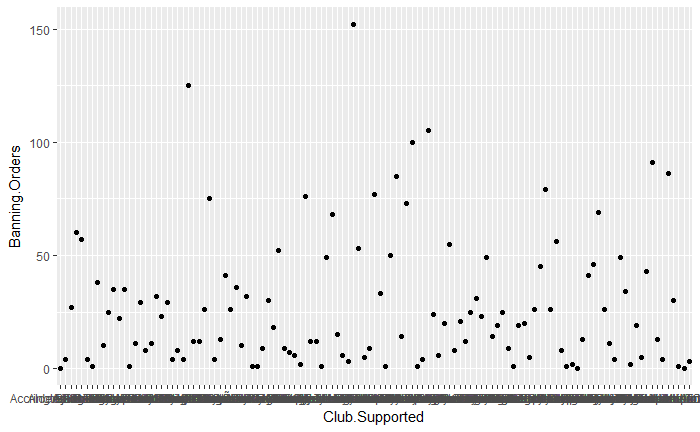

The first line above begins a plot by calling the `ggplot()` function, and putting the data into it. On the second line, within the `aes()` command, you pass the specific variables which you want to plot. In this case, we are only plotting one variable (clubs) against another (banning orders).

On the third line, we add the geometry. This is where we tell R what we want the graph to be. In other words: what type of graph do we want to represent the two variables? Here, we say we want it to be points. Because we have already specified the data and the variables, the `geom_point()` command is empty - it already has the basic information required. You can see a list of all possible geoms [here](http://docs.ggplot2.org/current/).

We can tweak the display of the graph by using the coordinates layer. Here I used theme_bw() which is a nice clean theme. You can try with other themes. To get a list of themes you can also see the resource [here](http://docs.ggplot2.org/current/).

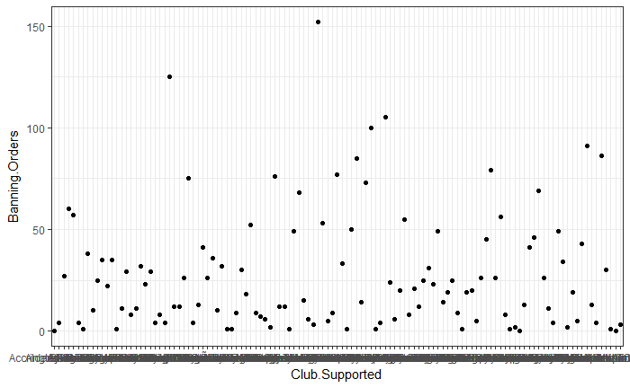

This theme element can do a lot more. For example, here you can’t really read the axis labels because they’re all overlapping. One solution would be to rotate your axis labels 90 degrees, with the following code: `axis.text.x = element_text(angle = 90, hjust = 1)`. You pass this code to the theme argument.

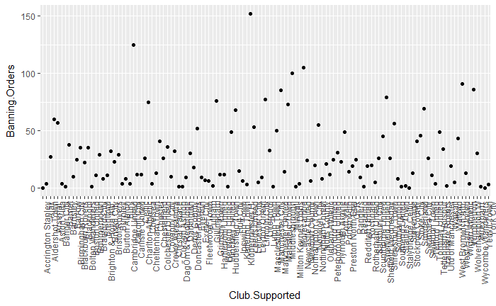

OK what if we don’t want it to be points, but instead we wanted it to be a bar graph?

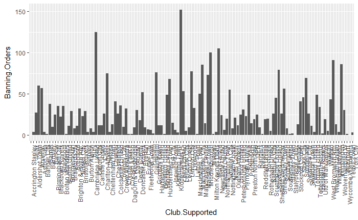

You might notice here we pass an argument `stat = "identity"` to `geom_bar()` function. This is because you can have a bar graph where the height of the bar shows frequency (stat = “count”), or where the height is taken from a variable in your dataframe (stat = “identity”). Here we specified a y-value (height) as the Banning.Orders variable.

So this is cool! But what if I like both?

Well this is the beauty of the layering approach of ggplot2. You can layer on as many geoms as your heart desires!

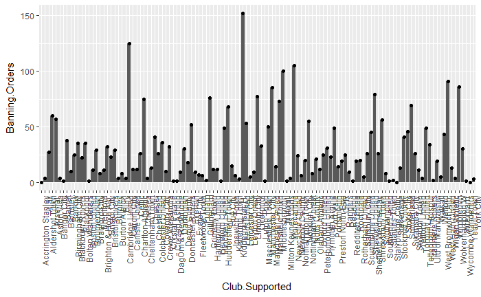

This is basically all you need to know to build a graph!

#What graph should I use?

There are a lot of points to consider when you are choosing what graph to use to visually represent your data. There are some best practice guidelines, but at the end of the day, you need to consider what is best for your data. What do you want to show? What graph will best communicate your message? Is it a comparison between groups? Is it the frequency distribution of one variable?

As some guidance, you can use the below [cheatsheet, taken from Nathan Yau’s blog Flowingdata](https://flowingdata.com/2009/01/15/flow-chart-shows-you-what-chart-to-use/):

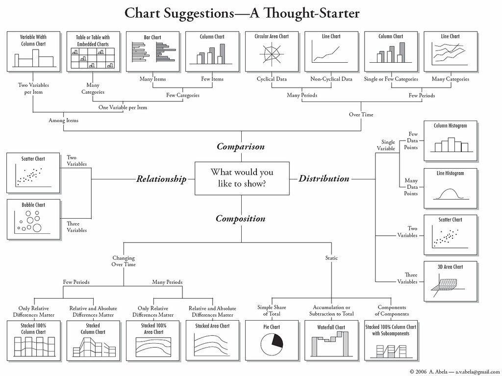

However, keep in mind that this is more of a guideline, aimed to nudge you in the right direction. There are many ways to visualise the same data, and sometimes you might want to experiment with some of these, see what the differences are.

There is also a vast amount of research into what works in displaying quantitative information. The classic book is [The Visual Dispay of Quantitative Information by Edward Tufte](https://www.edwardtufte.com/tufte/books_vdqi), but since him there have been many other researchers who focus on approaches to displaying data.

They tend to result in recommendations on what to use (and not use) in certain contexts

For example, most data visualisation experts agree that you should not use 3D graphics unless there is a meaning to the third dimension. So using 3D graphics just for decoration, as in [this case](https://mir-s3-cdn-cf.behance.net/project_modules/disp/2505dd10837923.56030acd2ef20.jpg) is normally frowed upon. However there are cases when including a third dimension is vital to communicating your findings. See this [example](http://www.visualisingdata.com/2015/03/when-3d-works/).

Also often certain chart types are villainised. The pie chart is one such example. A lot of people really dislike piecharts, eg see [here](http://www.storytellingwithdata.com/blog/2011/07/death-to-pie-charts) or [here](http://www.businessinsider.com/pie-charts-are-the-worst-2013-6?IR=T). If you want to display proportion, research indicates that a square pie chart is more likely to be interpreted correctly by viewers: [see here](https://eagereyes.org/blog/2016/a-reanalysis-of-a-study-about-square-pie-charts-from-2009)

Also, in some cases bar plots can hide important features of your data, and might not be the most appropriate means for comparison:

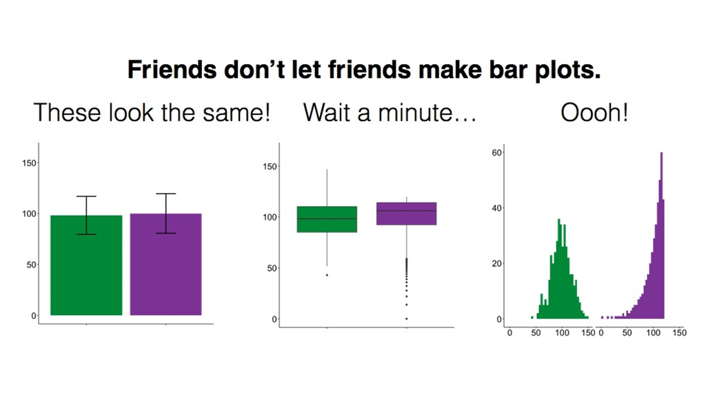

This has lead to a [kickstarter campaign](https://www.kickstarter.com/projects/1474588473/barbarplots/description) around actually banning bar plots…!

In any case, the plot that you use depends on the data you are plotting, as well as the message you want to convey with the plot.

So for example, returning again to the difference between number of banning orders between clubs in different leagues, what are some ways of plotting these?

One suggestion is to make a histogram for each one. You can use ggplot’s facet_wrap() option to split graphs by a grouping variable. For example, to create a histogram of banning orders you write:

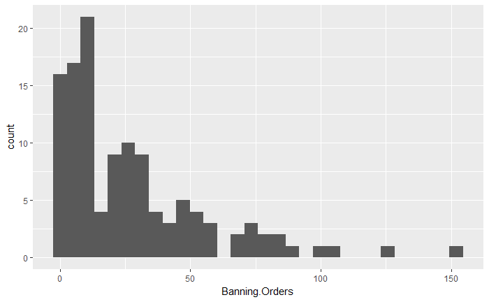

We’ll now go through some examples of making graphs using ggplot package.

#Histograms

[Histograms](http://www.learner.org/courses/againstallodds/unitpages/unit03.html) are useful ways of representing quantitative variables visually.

As mentioned earlier, we will emphasise in this course the use of the `ggplot()` function. With `ggplot()` you start with a blank canvass and keep adding specific layers. The `ggplot()` function can specify the dataset and the aesthetics (the visual characteristics that represent the data).

To get the data we’re going to use here, load up the package “gapminder”.

```r
library(gapminder)
```

This package has a dataframe called “gapminder”. This is an excerpt of the Gapminder data on life expectancy, GDP per capita, and population by country. To access the codebook (how you find out what variables are) use the “?”.

This dataframe has data from 1952 to 2007, but here we want to focus on just the most recent year. So let’s select only data from 2007:

```r
gapminder_2007 <- filter(gapminder, year==2007)
```

OK so let’s make a graph about the variable which represents the life expectancy by country (‘lifeExp’).

If you want to produce a histogram with the `ggplot` function, you would use the following equivalent code:

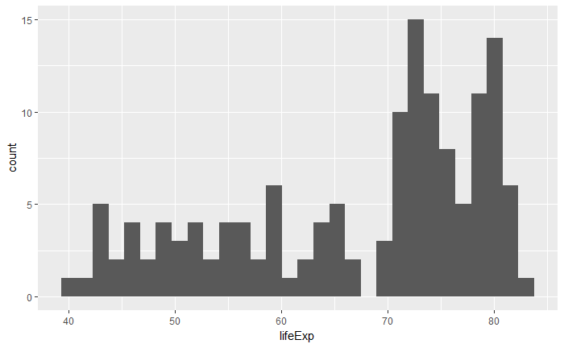

So you can see that `ggplot` works in a way that you can add a series of additional specifications (layers, annotations). In this simple plot the `ggplot` function simply maps *lifeExp* as the variable to be displayed (as one of the aesthetics) and the dataset. Then you add the `geom_histogram` to tell R that you want this variable to be represented as a histogram. Later we will see what other things you can add.

A histogram is simply putting cases in “bins” and then creates a bar for each bin. You can think of it as a visual grouped frequency distribution. Note that the default option for a histogram is a count on the Y axis, so we don’t actually need to specify what we want on the Y axis. The code we have used so far has used a bin-width of size range/30 as R kindly reminded us. But you can modify this parameter if you want to get a rougher or a more granular picture. In fact, you should *always* play around with different specifications of the bin-width until you find one that tells the full story in a parsimonious way.

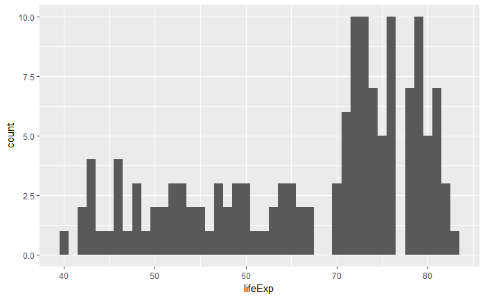

Using bin-width of 1 we are essentially creating a bar for every one unit increase in the life expectancy. We can see that most countries have life expectancy of 60 or over.

```
[1] 99
```

We can see that the large majority of countries, 99 out of 142, have a life expectancy over 60. But we can also see that there are some countries that have a low life expectancies. You can see how we can use visualisations to show the data and get a first feeling for how it may be distributed.

Often we visualise data because we want to compare distributions. **Most of data analysis is about making comparisons**. We are going to explore whether the life expectancy is different for less affluent countries. The variable *gdpPercap* measures the country’s GDP per capita. For the purposes of this illustration I want to dichotomise this variable. We’ve covered data manipulation already, so you hopefully you can remember the `ifelse` command used below. Here we will be grouping anything that’s got GDP higher than the mean as “high gdp”, and everything else as “low gdp”.

```r
gapminder_2007 <- gapminder_2007 %>%
  mutate(gdp_factor = if_else(gdpPercap > mean(gdpPercap), "high gdp", "low gdp"))

gapminder_2007$gdp_factor <- as.factor(gapminder_2007$gdp_factor) #The variable we created was a character vector, this step transforms it into a factor (many functions designed to work with categorical variables expect a factor as an input, not just a character vector).
```

Now we can produce the plot:

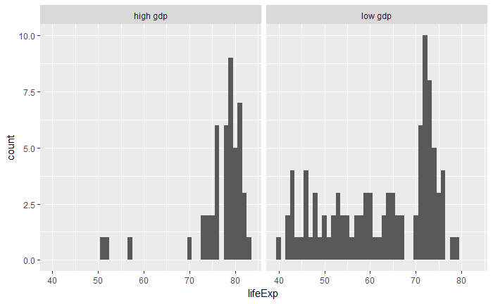

Instead of using facets, we could overlay the histograms with a bit of transparency. Transparencies work better in screens than in printed document, so keep in mind this when deciding whether to use them instead of facets. The code is as follows:

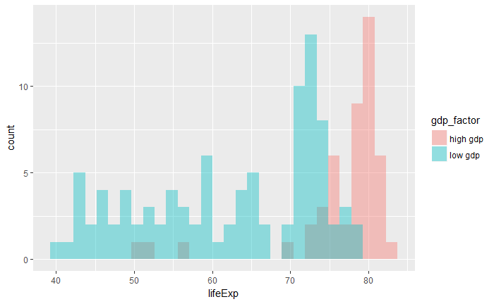

#Density plots

For smoother distributions seen in a histogram, you can use density plots. You should have a healthy amount of data to use these or you could end up with a lot of unwanted noise. Let’s first look at the single density plot for all cases:

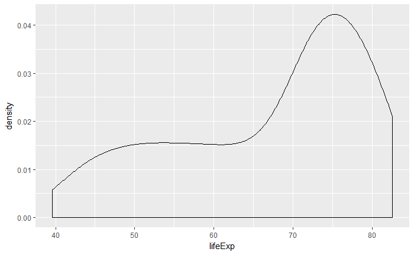

In a density plot the area under the lines sum to 1 and the Y, vertical, axis now gives you the estimated probability for the values in the X, horizontal, axis. As you can observe, it provides a smoother representation of the distribution (as compared to the histograms).

You can also use this to compare the distribution of a quantitative variable across the levels in a categorical variable (factor):

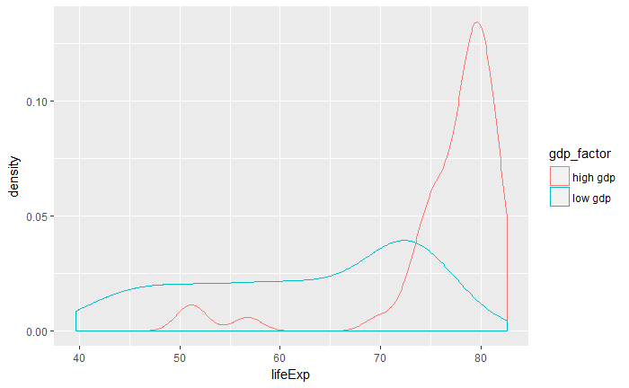

Or you could use transparencies:

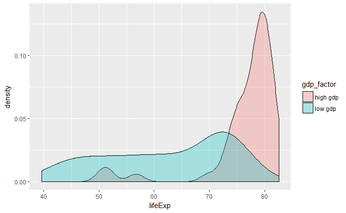

Did you notice the difference with the comparative histograms? By using density plots we are rescaling to ensure the same area for each of the levels in our grouping variable. This makes it easier to compare two groups that have different frequencies. The areas under the curve add up to 1 for both of the groups, whereas in the histogram the area within the bars represent the number of cases in each of the groups. If you have many more cases in one group than the other it may be difficult to make comparisons or to clearly see the distribution for the group with fewer cases. So, this is one of the reasons why you may want to use density plots.

#Box plots

[Box plots](http://tomhopper.me/2014/07/04/the-most-useful-data-plot-youve-never-used/) are an interesting way of presenting the 5 number summary in a visual way. For this illustration, I am going to display the distribution of the GDP in the various countries:

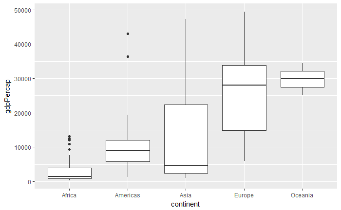

With a boxplot like this you can see straight away that continents differ from one another.

#Scatter plots with two variables

When looking at the relationship between two quantitative variables, nothing beats the **scatterplot**. [This](http://www.datavis.ca/papers/friendly-scat.pdf) is a lovely article in the history of the scatterplot!

A scatterplot plots one variable in the Y axis, and another in the X axis. Typically, if you have a clear outcome or response variable in mind, you place it in the Y axis, and you place the explanatory variable in the X axis.

This is how you produce a scatterplot with `ggplot()`:

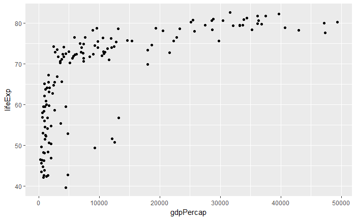

Each point represents a case in our dataset and the coordinates attached to it in this two dimensional plane are given by their value in the Y (life expectancy) and X (GDP per capita) variables.

One of the things you may notice with a scatterplot is that even with a smallish dataset such as this, with just about 142 cases, **overplotting** may be a problem. When you have many cases with similar (or even worse the same) value, it is difficult to tell them apart. There’s a variety of ways of dealing with overplotting. One possibility is to add some **transparency** to the points:

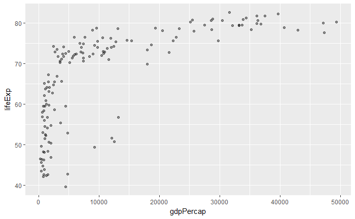

One way of dealing with this particular problem is by **jittering**. Jittering is the act of adding random noise to data in order to prevent overplotting in statistical graphs. In `ggplot` one way of doing this is by passing an argument to `geom_point` specifying you want to jitter the points. This will introduce some random noise so that age looks less discrete, but doesn’t alter the general pattern observed.

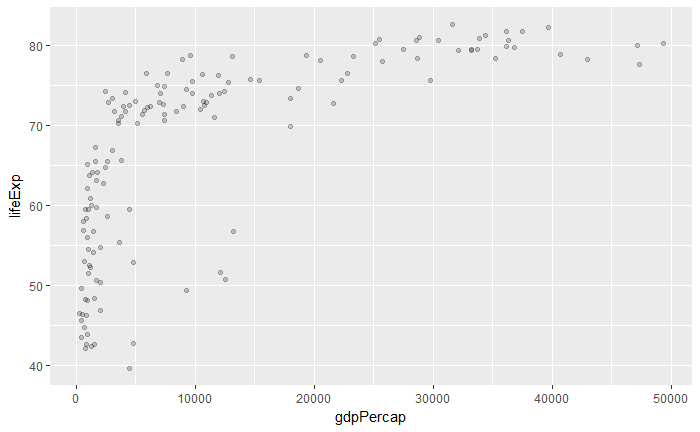

Another alternative for solving overplotting is to **bin the data** into rectangles and map the density of the points to the fill of the colour of the rectangles.

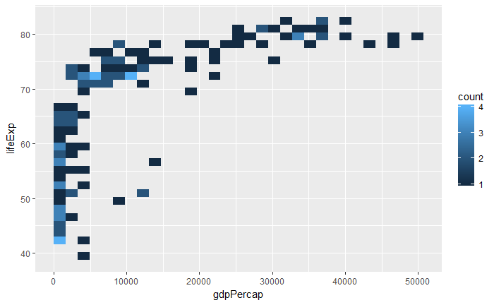

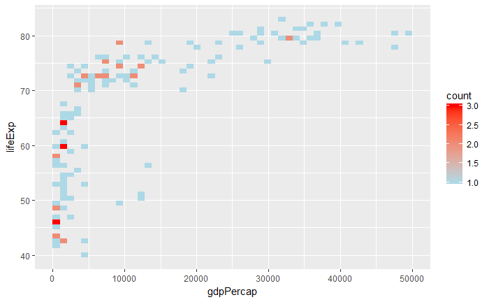

What this is doing is creating boxes within the two dimensional plane; counting the number of points within those boxes; and attaching a colour (fill) to the box in function of the density of points within each of the rectangles.

When looking at scatterplots, sometimes it is useful to summarise the relationships by mean of drawing lines. You could for example add a line representing the **conditional mean**. A conditional mean is simply mean of your Y variable for each value of X. We can ask R to plot a line connecting these means using `geom_line()` and specifying you want the conditional means.

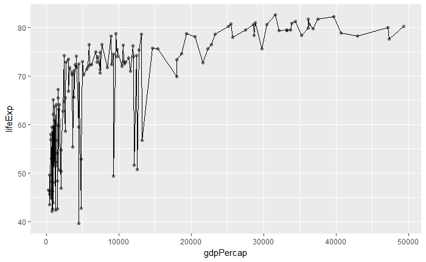

With only 142 cases there are loads of ups and downs. If you have many more cases for each level of X the line would look less rough. You can, in any case, produce a smoother line using `geom_smooth` instead. This is computed using the “loess” method. A [Loess regression line](http://en.wikipedia.org/wiki/Local_regression) subsets chunks of data around your X axis to try to estimate a regression line that fits well a region of the data.

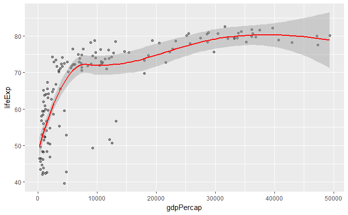

As you can see here you produce a smoother line than with the conditional means. The line, as the scatterplot, seems to be suggesting an overall curvilinear relationship that almost flattens out once the GDP is around 30,000.

##Scatter plots conditioning in a third variable

There are various ways to plot a third variable in a scatterplot. You could go 3D and in some contexts that may be appropriate. But more often than not it is preferable to use only a two dimensional plot.

If you have a grouping variable you could map it to the colour of the points as one of the aesthetics arguments. Here we return to the Gapminder scatterplot but will add a third variable, that indicates the continent.

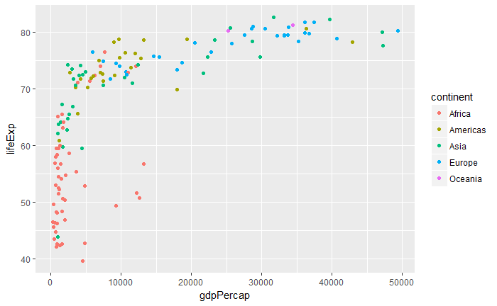

We can see distinct differences between continents.